# R for Citizen Data Scientists

Nick V. Flor

December 31, 2020

**Nick V. Flor**  
Mental Systems Research Lab  
professorf@mentalsystemsinc.com

Before we start, it’s important to know the difference between data and information. Data is basically anything you can perceive. But it’s not information until you can use it—until it’s useful.

For example, a list of a stock’s prices is simply data until you notice a trend that tells you to buy or sell; that trend in the stock prices is information. In video games, a boss’s movements are data until you notice a pattern that tells you how to dodge or strike; that “tell” is information.

Simply put, data is potential information. And information is useful data.

Something needs to transform the data into information, and that something is a computer program.

A computer program is a sequence of instructions that transforms data into information. A computer program can also store data, e.g., into a database, or forward the data, e.g., across a network.

But the prime directive, the sine qua non, the essential function of a computer program is to transform data into information.

But where do you the computer program? The answer is: from a computer programmer.

Programming is the activity by computer programmers, which results in a sequence of instructions that a computer can use to transform data into information.

```r
# Open a csv file into a data frame
df=read.csv("HPQ.csv") # df is a VARIABLE, read.csv is a FUNCTION, "hp.csv" is a PARAMETER

# Display
df
```

| Date | Open | High | Low | Close | Adj.Close | Volume |
| --- | --- | --- | --- | --- | --- | --- |
| 2019-12-24 | 20.56 | 20.74 | 20.56 | 20.59 | 19.85241 | 3064900 |
| 2019-12-26 | 20.62 | 20.80 | 20.61 | 20.69 | 19.94882 | 3729700 |
| 2019-12-27 | 20.69 | 20.73 | 20.51 | 20.53 | 19.79456 | 4780500 |
| 2019-12-30 | 20.50 | 20.64 | 20.39 | 20.49 | 19.75599 | 4458000 |
| 2019-12-31 | 20.41 | 20.57 | 20.33 | 20.55 | 19.81384 | 6282100 |
| 2020-01-02 | 20.68 | 20.83 | 20.65 | 20.79 | 20.04524 | 7194700 |
| 2020-01-03 | 20.48 | 20.68 | 20.45 | 20.53 | 19.79456 | 5421800 |
| 2020-01-06 | 20.66 | 20.79 | 20.51 | 20.61 | 19.87169 | 9312500 |
| 2020-01-07 | 20.56 | 20.78 | 20.51 | 20.66 | 19.91990 | 6536200 |
| 2020-01-08 | 20.53 | 20.99 | 20.53 | 20.93 | 20.18023 | 7780100 |

[output cut: 243 more lines]

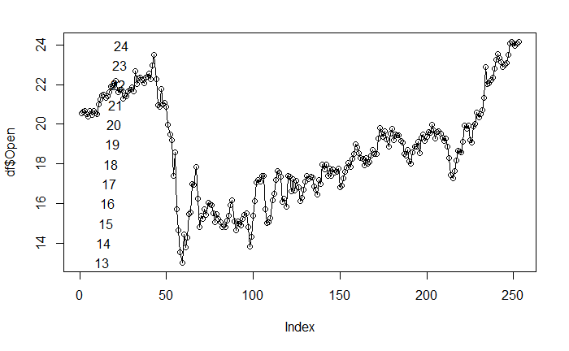

```r
plot(df$Open, type="o")
text(1:length(df$Open))
```

```r
sum(df$Open)
```

```
[1] 4743.61
```

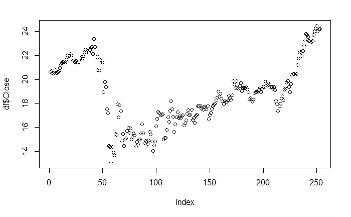

```r
plot(df$Close)
```

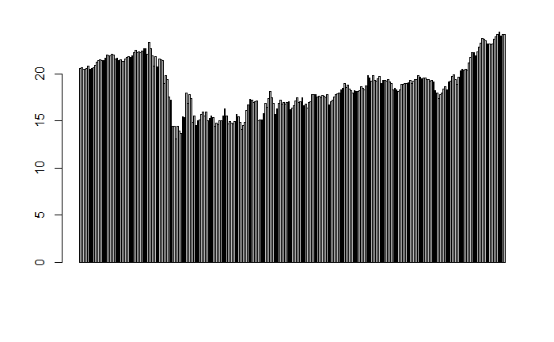

```r
barplot(df$Close)
```

You can also read a file directly from a URL

```r
DataFrame=read.csv("https://raw.githubusercontent.com/CSSEGISandData/COVID-19/master/csse_covid_19_data/csse_covid_19_time_series/time_series_covid19_confirmed_global.csv")
DataFrame
```

| Province.State | Country.Region | Lat | Long | X1.22.20 | X1.23.20 | X1.24.20 | X1.25.20 | X1.26.20 | X1.27.20 | X1.28.20 | X1.29.20 | X1.30.20 | X1.31.20 | X2.1.20 | X2.2.20 | X2.3.20 | X2.4.20 | X2.5.20 | X2.6.20 | X2.7.20 | X2.8.20 | X2.9.20 | X2.10.20 | X2.11.20 | X2.12.20 | X2.13.20 | X2.14.20 | X2.15.20 | X2.16.20 | … |
| --- | --- | --- | --- | --- | --- | --- | --- | --- | --- | --- | --- | --- | --- | --- | --- | --- | --- | --- | --- | --- | --- | --- | --- | --- | --- | --- | --- | --- | --- | --- |
|  | Afghanistan | 33.939110 | 67.709953 | 0 | 0 | 0 | 0 | 0 | 0 | 0 | 0 | 0 | 0 | 0 | 0 | 0 | 0 | 0 | 0 | 0 | 0 | 0 | 0 | 0 | 0 | 0 | 0 | 0 | 0 | … |
|  | Albania | 41.153300 | 20.168300 | 0 | 0 | 0 | 0 | 0 | 0 | 0 | 0 | 0 | 0 | 0 | 0 | 0 | 0 | 0 | 0 | 0 | 0 | 0 | 0 | 0 | 0 | 0 | 0 | 0 | 0 | … |
|  | Algeria | 28.033900 | 1.659600 | 0 | 0 | 0 | 0 | 0 | 0 | 0 | 0 | 0 | 0 | 0 | 0 | 0 | 0 | 0 | 0 | 0 | 0 | 0 | 0 | 0 | 0 | 0 | 0 | 0 | 0 | … |
|  | Andorra | 42.506300 | 1.521800 | 0 | 0 | 0 | 0 | 0 | 0 | 0 | 0 | 0 | 0 | 0 | 0 | 0 | 0 | 0 | 0 | 0 | 0 | 0 | 0 | 0 | 0 | 0 | 0 | 0 | 0 | … |
|  | Angola | -11.202700 | 17.873900 | 0 | 0 | 0 | 0 | 0 | 0 | 0 | 0 | 0 | 0 | 0 | 0 | 0 | 0 | 0 | 0 | 0 | 0 | 0 | 0 | 0 | 0 | 0 | 0 | 0 | 0 | … |
|  | Antigua and Barbuda | 17.060800 | -61.796400 | 0 | 0 | 0 | 0 | 0 | 0 | 0 | 0 | 0 | 0 | 0 | 0 | 0 | 0 | 0 | 0 | 0 | 0 | 0 | 0 | 0 | 0 | 0 | 0 | 0 | 0 | … |
|  | Argentina | -38.416100 | -63.616700 | 0 | 0 | 0 | 0 | 0 | 0 | 0 | 0 | 0 | 0 | 0 | 0 | 0 | 0 | 0 | 0 | 0 | 0 | 0 | 0 | 0 | 0 | 0 | 0 | 0 | 0 | … |
|  | Armenia | 40.069100 | 45.038200 | 0 | 0 | 0 | 0 | 0 | 0 | 0 | 0 | 0 | 0 | 0 | 0 | 0 | 0 | 0 | 0 | 0 | 0 | 0 | 0 | 0 | 0 | 0 | 0 | 0 | 0 | … |
| Australian Capital Territory | Australia | -35.473500 | 149.012400 | 0 | 0 | 0 | 0 | 0 | 0 | 0 | 0 | 0 | 0 | 0 | 0 | 0 | 0 | 0 | 0 | 0 | 0 | 0 | 0 | 0 | 0 | 0 | 0 | 0 | 0 | … |
| New South Wales | Australia | -33.868800 | 151.209300 | 0 | 0 | 0 | 0 | 3 | 4 | 4 | 4 | 4 | 4 | 4 | 4 | 4 | 4 | 4 | 4 | 4 | 4 | 4 | 4 | 4 | 4 | 4 | 4 | 4 | 4 | … |

[output cut: 261 more lines]